# Project: The Movie Database (TMDb) Data Analysis

- Introduction
- Data Wrangling
- Exploratory Data Analysis
- Conclusions

## Introduction

### Data Overview

> The data is collected from The Movie Databese (TMDb) API. The product uses the TMDb API but is not endorsed or certified by TMDb. The API provides access to data on many movies, actors and actresses, crew members, and TV shows as well as budgets and revenues. This dataset contains information about 10,000 movies collected from The Movie Database (TMDb), including user ratings and revenue. We shall analyze this data to dig into some of the important industry questions like what can we say about the success of a movie before it is released?

> Note that budget_adj (budget adjusted) and revenue_adj (revenue adjusted) columns show the budget and revenue of the associated movie in terms of 2010 dollars, accounting for inflation over time.

### Relevant questions we could ask about the data

> 1. Which genres are most popular from year to year?
> 2. What kinds of properties are associated with movies that have high revenues?

```python
# Use this cell to set up import statements for all of the packages that you
#   plan to use.
import numpy as np
import pandas as pd
import matplotlib.pyplot as plt
import seaborn as sns
% matplotlib inline
sns.set_style ('darkgrid')

# Remember to include a 'magic word' so that your visualizations are plotted
#   inline with the notebook. See this page for more:
#   http://ipython.readthedocs.io/en/stable/interactive/magics.html
```

## Data Wrangling

### General Properties

> **Features And Counts**
> 1. Samples (rows) = 10866
> 2. Variables(columns) = 21
> 3. Duplicate rows = 1
> 4. Rows with missing data = 7930

```python
# Load your data and print out a few lines. Perform operations to inspect data
df = pd.read_csv('tmdb_movies.csv')
df.head()

#   types and look for instances of missing or possibly errant data.
```

|  | id | imdb_id | popularity | budget | revenue | original_title | cast | homepage | director | tagline | ... | overview | runtime | genres | production_companies | release_date | vote_count | vote_average | release_year | budget_adj | revenue_adj |
| --- | --- | --- | --- | --- | --- | --- | --- | --- | --- | --- | --- | --- | --- | --- | --- | --- | --- | --- | --- | --- | --- |
| 0 | 135397 | tt0369610 | 32.985763 | 150000000 | 1513528810 | Jurassic World | Chris Pratt\|Bryce Dallas Howard\|Irrfan Khan\|Vi... | http://www.jurassicworld.com/ | Colin Trevorrow | The park is open. | ... | Twenty-two years after the events of Jurassic ... | 124 | Action\|Adventure\|Science Fiction\|Thriller | Universal Studios\|Amblin Entertainment\|Legenda... | 6/9/15 | 5562 | 6.5 | 2015 | 1.379999e+08 | 1.392446e+09 |
| 1 | 76341 | tt1392190 | 28.419936 | 150000000 | 378436354 | Mad Max: Fury Road | Tom Hardy\|Charlize Theron\|Hugh Keays-Byrne\|Nic... | http://www.madmaxmovie.com/ | George Miller | What a Lovely Day. | ... | An apocalyptic story set in the furthest reach... | 120 | Action\|Adventure\|Science Fiction\|Thriller | Village Roadshow Pictures\|Kennedy Miller Produ... | 5/13/15 | 6185 | 7.1 | 2015 | 1.379999e+08 | 3.481613e+08 |
| 2 | 262500 | tt2908446 | 13.112507 | 110000000 | 295238201 | Insurgent | Shailene Woodley\|Theo James\|Kate Winslet\|Ansel... | http://www.thedivergentseries.movie/#insurgent | Robert Schwentke | One Choice Can Destroy You | ... | Beatrice Prior must confront her inner demons ... | 119 | Adventure\|Science Fiction\|Thriller | Summit Entertainment\|Mandeville Films\|Red Wago... | 3/18/15 | 2480 | 6.3 | 2015 | 1.012000e+08 | 2.716190e+08 |
| 3 | 140607 | tt2488496 | 11.173104 | 200000000 | 2068178225 | Star Wars: The Force Awakens | Harrison Ford\|Mark Hamill\|Carrie Fisher\|Adam D... | http://www.starwars.com/films/star-wars-episod... | J.J. Abrams | Every generation has a story. | ... | Thirty years after defeating the Galactic Empi... | 136 | Action\|Adventure\|Science Fiction\|Fantasy | Lucasfilm\|Truenorth Productions\|Bad Robot | 12/15/15 | 5292 | 7.5 | 2015 | 1.839999e+08 | 1.902723e+09 |
| 4 | 168259 | tt2820852 | 9.335014 | 190000000 | 1506249360 | Furious 7 | Vin Diesel\|Paul Walker\|Jason Statham\|Michelle ... | http://www.furious7.com/ | James Wan | Vengeance Hits Home | ... | Deckard Shaw seeks revenge against Dominic Tor... | 137 | Action\|Crime\|Thriller | Universal Pictures\|Original Film\|Media Rights ... | 4/1/15 | 2947 | 7.3 | 2015 | 1.747999e+08 | 1.385749e+09 |

5 rows × 21 columns

```python
df.tail(20)
```

|  | id | imdb_id | popularity | budget | revenue | original_title | cast | homepage | director | tagline | ... | overview | runtime | genres | production_companies | release_date | vote_count | vote_average | release_year | budget_adj | revenue_adj |
| --- | --- | --- | --- | --- | --- | --- | --- | --- | --- | --- | --- | --- | --- | --- | --- | --- | --- | --- | --- | --- | --- |
| 10846 | 17102 | tt0059127 | 0.212716 | 0 | 0 | Dracula: Prince of Darkness | Christopher Lee\|Barbara Shelley\|Andrew Keir\|Fr... | NaN | Terence Fisher | DEAD for Ten Years DRACULA, Prince of Darkness... | ... | Whilst vacationing in the Carpathian Mountain,... | 90 | Horror | Seven Arts Productions\|Hammer Film Productions | 1/9/66 | 16 | 5.7 | 1966 | 0.000000e+00 | 0.000000e+00 |
| 10847 | 28763 | tt0060548 | 0.034555 | 0 | 0 | Island of Terror | Peter Cushing\|Edward Judd\|Carole Gray\|Eddie By... | NaN | Terence Fisher | How could they stop the devouring death...that... | ... | A small island community is overrun with creep... | 89 | Science Fiction\|Horror | Planet Film Productions\|Protelco | 6/20/66 | 13 | 5.3 | 1966 | 0.000000e+00 | 0.000000e+00 |
| 10848 | 2161 | tt0060397 | 0.207257 | 5115000 | 12000000 | Fantastic Voyage | Stephen Boyd\|Raquel Welch\|Edmond O'Brien\|Donal... | NaN | Richard Fleischer | A Fantastic and Spectacular Voyage... Through ... | ... | The science of miniaturization has been unlock... | 100 | Adventure\|Science Fiction | Twentieth Century Fox Film Corporation | 8/24/66 | 42 | 6.7 | 1966 | 3.436265e+07 | 8.061618e+07 |
| 10849 | 28270 | tt0060445 | 0.206537 | 0 | 0 | Gambit | Michael Caine\|Shirley MacLaine\|Herbert Lom\|Joh... | NaN | Ronald Neame | Shirley MacLaine raises Michael Caine! | ... | Harry Dean (Michael Caine) has a perfect plan ... | 109 | Action\|Comedy\|Crime | Universal Pictures | 12/16/66 | 14 | 6.1 | 1966 | 0.000000e+00 | 0.000000e+00 |
| 10850 | 26268 | tt0060490 | 0.202473 | 0 | 0 | Harper | Paul Newman\|Lauren Bacall\|Julie Harris\|Arthur ... | NaN | Jack Smight | Harper takes a case - and the payoff is murder. | ... | Harper is a cynical private eye in the best tr... | 121 | Action\|Drama\|Thriller\|Crime\|Mystery | Warner Bros. | 2/23/66 | 14 | 6.0 | 1966 | 0.000000e+00 | 0.000000e+00 |
| 10851 | 15347 | tt0060182 | 0.342791 | 0 | 0 | Born Free | Virginia McKenna\|Bill Travers\|Geoffrey Keen\|Pe... | NaN | James Hill | From The Pages Of The Beloved Best Seller... A... | ... | Born Free (1966) is an Open Road Films Ltd./Co... | 95 | Adventure\|Drama\|Action\|Family\|Foreign | High Road | 6/22/66 | 15 | 6.6 | 1966 | 0.000000e+00 | 0.000000e+00 |
| 10852 | 37301 | tt0060165 | 0.227220 | 0 | 0 | A Big Hand for the Little Lady | Henry Fonda\|Joanne Woodward\|Jason Robards\|Paul... | NaN | Fielder Cook | All the action you can take...all the adventur... | ... | A naive traveler in Laredo gets involved in a ... | 95 | Western | Eden Productions Inc. | 5/31/66 | 11 | 6.0 | 1966 | 0.000000e+00 | 0.000000e+00 |
| 10853 | 15598 | tt0060086 | 0.163592 | 0 | 0 | Alfie | Michael Caine\|Shelley Winters\|Millicent Martin... | NaN | Lewis Gilbert | Is any man an Alfie? Ask any girl! | ... | The film tells the story of a young man who le... | 114 | Comedy\|Drama\|Romance | NaN | 3/29/66 | 26 | 6.2 | 1966 | 0.000000e+00 | 0.000000e+00 |
| 10854 | 31602 | tt0060232 | 0.146402 | 0 | 0 | The Chase | Marlon Brando\|Jane Fonda\|Robert Redford\|E.G. M... | NaN | Arthur Penn | The chase is on! | ... | Most everyone in town thinks that Sheriff Cald... | 135 | Thriller\|Drama\|Crime | Horizon Pictures\|Columbia Pictures Corporation | 2/17/66 | 17 | 6.0 | 1966 | 0.000000e+00 | 0.000000e+00 |
| 10855 | 13343 | tt0059221 | 0.141026 | 700000 | 0 | The Ghost & Mr. Chicken | Don Knotts\|Joan Staley\|Liam Redmond\|Dick Sarge... | NaN | Alan Rafkin | G-G-GUARANTEED! YOU'LL BE SCARED UNTIL YOU LAU... | ... | Luther Heggs aspires to being a reporter for h... | 90 | Comedy\|Family\|Mystery\|Romance | Universal Pictures | 1/20/66 | 14 | 6.1 | 1966 | 4.702610e+06 | 0.000000e+00 |
| 10856 | 20277 | tt0061135 | 0.140934 | 0 | 0 | The Ugly Dachshund | Dean Jones\|Suzanne Pleshette\|Charles Ruggles\|K... | NaN | Norman Tokar | A HAPPY HONEYMOON GOES TO THE DOGS!...When a G... | ... | The Garrisons (Dean Jones and Suzanne Pleshett... | 93 | Comedy\|Drama\|Family | Walt Disney Pictures | 2/16/66 | 14 | 5.7 | 1966 | 0.000000e+00 | 0.000000e+00 |
| 10857 | 5921 | tt0060748 | 0.131378 | 0 | 0 | Nevada Smith | Steve McQueen\|Karl Malden\|Brian Keith\|Arthur K... | NaN | Henry Hathaway | Some called him savage- and some called him sa... | ... | Nevada Smith is the young son of an Indian mot... | 128 | Action\|Western | Paramount Pictures\|Solar Productions\|Embassy P... | 6/10/66 | 10 | 5.9 | 1966 | 0.000000e+00 | 0.000000e+00 |
| 10858 | 31918 | tt0060921 | 0.317824 | 0 | 0 | The Russians Are Coming, The Russians Are Coming | Carl Reiner\|Eva Marie Saint\|Alan Arkin\|Brian K... | NaN | Norman Jewison | IT'S A PLOT! ...to make the world die laughing!! | ... | Without hostile intent, a Soviet sub runs agro... | 126 | Comedy\|War | The Mirisch Corporation | 5/25/66 | 11 | 5.5 | 1966 | 0.000000e+00 | 0.000000e+00 |
| 10859 | 20620 | tt0060955 | 0.089072 | 0 | 0 | Seconds | Rock Hudson\|Salome Jens\|John Randolph\|Will Gee... | NaN | John Frankenheimer | NaN | ... | A secret organisation offers wealthy people a ... | 100 | Mystery\|Science Fiction\|Thriller\|Drama | Gibraltar Productions\|Joel Productions\|John Fr... | 10/5/66 | 22 | 6.6 | 1966 | 0.000000e+00 | 0.000000e+00 |
| 10860 | 5060 | tt0060214 | 0.087034 | 0 | 0 | Carry On Screaming! | Kenneth Williams\|Jim Dale\|Harry H. Corbett\|Joa... | NaN | Gerald Thomas | Carry On Screaming with the Hilarious CARRY ON... | ... | The sinister Dr Watt has an evil scheme going.... | 87 | Comedy | Peter Rogers Productions\|Anglo-Amalgamated Fil... | 5/20/66 | 13 | 7.0 | 1966 | 0.000000e+00 | 0.000000e+00 |
| 10861 | 21 | tt0060371 | 0.080598 | 0 | 0 | The Endless Summer | Michael Hynson\|Robert August\|Lord 'Tally Ho' B... | NaN | Bruce Brown | NaN | ... | The Endless Summer, by Bruce Brown, is one of ... | 95 | Documentary | Bruce Brown Films | 6/15/66 | 11 | 7.4 | 1966 | 0.000000e+00 | 0.000000e+00 |
| 10862 | 20379 | tt0060472 | 0.065543 | 0 | 0 | Grand Prix | James Garner\|Eva Marie Saint\|Yves Montand\|Tosh... | NaN | John Frankenheimer | Cinerama sweeps YOU into a drama of speed and ... | ... | Grand Prix driver Pete Aron is fired by his te... | 176 | Action\|Adventure\|Drama | Cherokee Productions\|Joel Productions\|Douglas ... | 12/21/66 | 20 | 5.7 | 1966 | 0.000000e+00 | 0.000000e+00 |
| 10863 | 39768 | tt0060161 | 0.065141 | 0 | 0 | Beregis Avtomobilya | Innokentiy Smoktunovskiy\|Oleg Efremov\|Georgi Z... | NaN | Eldar Ryazanov | NaN | ... | An insurance agent who moonlights as a carthie... | 94 | Mystery\|Comedy | Mosfilm | 1/1/66 | 11 | 6.5 | 1966 | 0.000000e+00 | 0.000000e+00 |
| 10864 | 21449 | tt0061177 | 0.064317 | 0 | 0 | What's Up, Tiger Lily? | Tatsuya Mihashi\|Akiko Wakabayashi\|Mie Hama\|Joh... | NaN | Woody Allen | WOODY ALLEN STRIKES BACK! | ... | In comic Woody Allen's film debut, he took the... | 80 | Action\|Comedy | Benedict Pictures Corp. | 11/2/66 | 22 | 5.4 | 1966 | 0.000000e+00 | 0.000000e+00 |
| 10865 | 22293 | tt0060666 | 0.035919 | 19000 | 0 | Manos: The Hands of Fate | Harold P. Warren\|Tom Neyman\|John Reynolds\|Dian... | NaN | Harold P. Warren | It's Shocking! It's Beyond Your Imagination! | ... | A family gets lost on the road and stumbles up... | 74 | Horror | Norm-Iris | 11/15/66 | 15 | 1.5 | 1966 | 1.276423e+05 | 0.000000e+00 |

20 rows × 21 columns

```python
# exploring the overall dataset to discover fixes
df.describe()
```

|  | id | popularity | budget | revenue | runtime | vote_count | vote_average | release_year | budget_adj | revenue_adj |
| --- | --- | --- | --- | --- | --- | --- | --- | --- | --- | --- |
| count | 10866.000000 | 10866.000000 | 1.086600e+04 | 1.086600e+04 | 10866.000000 | 10866.000000 | 10866.000000 | 10866.000000 | 1.086600e+04 | 1.086600e+04 |
| mean | 66064.177434 | 0.646441 | 1.462570e+07 | 3.982332e+07 | 102.070863 | 217.389748 | 5.974922 | 2001.322658 | 1.755104e+07 | 5.136436e+07 |
| std | 92130.136561 | 1.000185 | 3.091321e+07 | 1.170035e+08 | 31.381405 | 575.619058 | 0.935142 | 12.812941 | 3.430616e+07 | 1.446325e+08 |
| min | 5.000000 | 0.000065 | 0.000000e+00 | 0.000000e+00 | 0.000000 | 10.000000 | 1.500000 | 1960.000000 | 0.000000e+00 | 0.000000e+00 |
| 25% | 10596.250000 | 0.207583 | 0.000000e+00 | 0.000000e+00 | 90.000000 | 17.000000 | 5.400000 | 1995.000000 | 0.000000e+00 | 0.000000e+00 |
| 50% | 20669.000000 | 0.383856 | 0.000000e+00 | 0.000000e+00 | 99.000000 | 38.000000 | 6.000000 | 2006.000000 | 0.000000e+00 | 0.000000e+00 |
| 75% | 75610.000000 | 0.713817 | 1.500000e+07 | 2.400000e+07 | 111.000000 | 145.750000 | 6.600000 | 2011.000000 | 2.085325e+07 | 3.369710e+07 |
| max | 417859.000000 | 32.985763 | 4.250000e+08 | 2.781506e+09 | 900.000000 | 9767.000000 | 9.200000 | 2015.000000 | 4.250000e+08 | 2.827124e+09 |

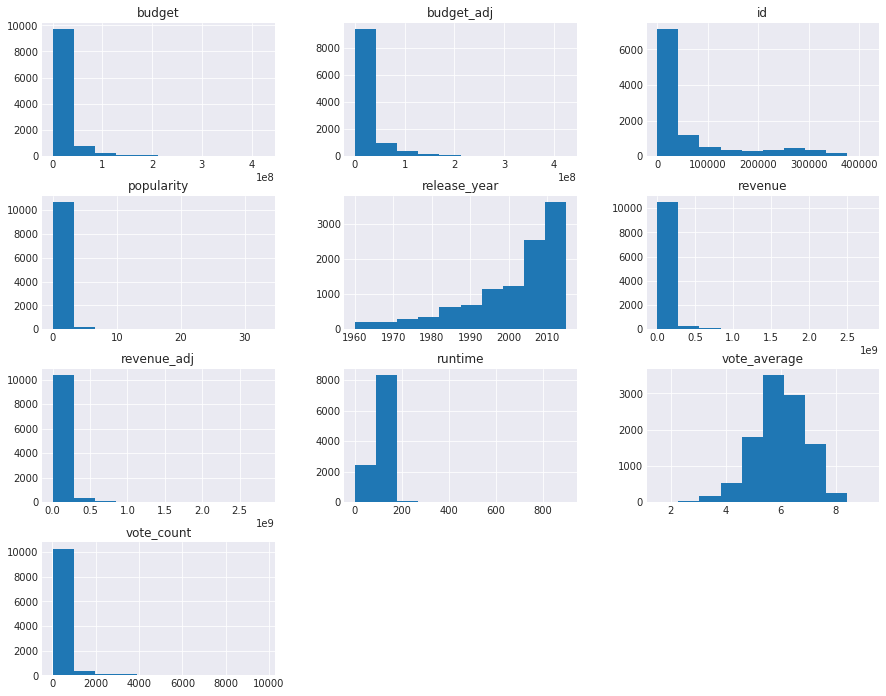

```python
# exploring the overall dataset with visuals
df.hist(figsize=(15, 12));
```

> release_year and vote_average are good variables to analyze this dataset because of their step-like skewness

```python
# to find number of samples, number of columns, datatypes of the variables, and missing values
df.info()
```

```
<class 'pandas.core.frame.DataFrame'>
RangeIndex: 10866 entries, 0 to 10865
Data columns (total 21 columns):
id                      10866 non-null int64
imdb_id                 10856 non-null object
popularity              10866 non-null float64
budget                  10866 non-null int64
revenue                 10866 non-null int64
original_title          10866 non-null object
cast                    10790 non-null object
homepage                2936 non-null object
director                10822 non-null object
tagline                 8042 non-null object
keywords                9373 non-null object
overview                10862 non-null object
runtime                 10866 non-null int64
genres                  10843 non-null object
production_companies    9836 non-null object
release_date            10866 non-null object
vote_count              10866 non-null int64
vote_average            10866 non-null float64
release_year            10866 non-null int64
budget_adj              10866 non-null float64
revenue_adj             10866 non-null float64
dtypes: float64(4), int64(6), object(11)
memory usage: 1.7+ MB
```

### Data Cleaning

```python
# to find number of duplicate rows
sum(df.duplicated())
```

```
1
```

```python
# to find number of unique values
df.nunique()
```

```
id                      10865
imdb_id                 10855
popularity              10814
budget                    557
revenue                  4702
original_title          10571
cast                    10719
homepage                 2896
director                 5067
tagline                  7997
keywords                 8804
overview                10847
runtime                   247
genres                   2039
production_companies     7445
release_date             5909
vote_count               1289
vote_average               72
release_year               56
budget_adj               2614
revenue_adj              4840
dtype: int64
```

#### 1. Cleaning Column Labels

> **Dropping extraneous columns**

> I dropped features that that are not relevant to the questions for my analysis.

> **imdb_id:** These values are not necessary in analyzing information within the table.

> **homepage, tagline, overview, keywords:** These values are unique to each row and cannot be used to make comparisons across multiple rows.

> **budget, revenue:** Since the **'budget_adj' and 'revenue_adj'** columns adjust the budget and revenue values in terms of 2010 dollars and will therefore allow for more accurate comparisons and analysis, these columns are not needed.

> **release_date:** I will be using release year to analyze this data, so this more specific column is not needed.

```python
# using pandas' drop function to drop columns from the dataset: 'id', 'imdb_id', 'homepage', 'tagline', 'keywords', 'overview', 'release_date'
df.drop(['imdb_id', 'homepage', 'tagline', 'keywords', 'overview', 'budget', 'revenue', 'release_date'], axis=1, inplace=True)
```

```python
df.head()
```

|  | id | popularity | original_title | cast | director | runtime | genres | production_companies | vote_count | vote_average | release_year | budget_adj | revenue_adj |
| --- | --- | --- | --- | --- | --- | --- | --- | --- | --- | --- | --- | --- | --- |
| 0 | 135397 | 32.985763 | Jurassic World | Chris Pratt\|Bryce Dallas Howard\|Irrfan Khan\|Vi... | Colin Trevorrow | 124 | Action\|Adventure\|Science Fiction\|Thriller | Universal Studios\|Amblin Entertainment\|Legenda... | 5562 | 6.5 | 2015 | 1.379999e+08 | 1.392446e+09 |
| 1 | 76341 | 28.419936 | Mad Max: Fury Road | Tom Hardy\|Charlize Theron\|Hugh Keays-Byrne\|Nic... | George Miller | 120 | Action\|Adventure\|Science Fiction\|Thriller | Village Roadshow Pictures\|Kennedy Miller Produ... | 6185 | 7.1 | 2015 | 1.379999e+08 | 3.481613e+08 |
| 2 | 262500 | 13.112507 | Insurgent | Shailene Woodley\|Theo James\|Kate Winslet\|Ansel... | Robert Schwentke | 119 | Adventure\|Science Fiction\|Thriller | Summit Entertainment\|Mandeville Films\|Red Wago... | 2480 | 6.3 | 2015 | 1.012000e+08 | 2.716190e+08 |
| 3 | 140607 | 11.173104 | Star Wars: The Force Awakens | Harrison Ford\|Mark Hamill\|Carrie Fisher\|Adam D... | J.J. Abrams | 136 | Action\|Adventure\|Science Fiction\|Fantasy | Lucasfilm\|Truenorth Productions\|Bad Robot | 5292 | 7.5 | 2015 | 1.839999e+08 | 1.902723e+09 |
| 4 | 168259 | 9.335014 | Furious 7 | Vin Diesel\|Paul Walker\|Jason Statham\|Michelle ... | James Wan | 137 | Action\|Crime\|Thriller | Universal Pictures\|Original Film\|Media Rights ... | 2947 | 7.3 | 2015 | 1.747999e+08 | 1.385749e+09 |

```python
df.info()
```

```
<class 'pandas.core.frame.DataFrame'>
RangeIndex: 10866 entries, 0 to 10865
Data columns (total 13 columns):
id                      10866 non-null int64
popularity              10866 non-null float64
original_title          10866 non-null object
cast                    10790 non-null object
director                10822 non-null object
runtime                 10866 non-null int64
genres                  10843 non-null object
production_companies    9836 non-null object
vote_count              10866 non-null int64
vote_average            10866 non-null float64
release_year            10866 non-null int64
budget_adj              10866 non-null float64
revenue_adj             10866 non-null float64
dtypes: float64(4), int64(4), object(5)
memory usage: 1.1+ MB
```

#### 2. Fixing Data Types

> I fixed **revenue_adj** and **budget_adj** datatypes

> Convert from float to int

```python
df['revenue_adj'] = df['revenue_adj'].astype(int)
df['budget_adj'] = df['budget_adj'].astype(int)
```

```python
df.head()
```

|  | id | popularity | original_title | cast | director | runtime | genres | production_companies | vote_count | vote_average | release_year | budget_adj | revenue_adj |
| --- | --- | --- | --- | --- | --- | --- | --- | --- | --- | --- | --- | --- | --- |
| 0 | 135397 | 32.985763 | Jurassic World | Chris Pratt\|Bryce Dallas Howard\|Irrfan Khan\|Vi... | Colin Trevorrow | 124 | Action\|Adventure\|Science Fiction\|Thriller | Universal Studios\|Amblin Entertainment\|Legenda... | 5562 | 6.5 | 2015 | 137999939 | 1392445892 |
| 1 | 76341 | 28.419936 | Mad Max: Fury Road | Tom Hardy\|Charlize Theron\|Hugh Keays-Byrne\|Nic... | George Miller | 120 | Action\|Adventure\|Science Fiction\|Thriller | Village Roadshow Pictures\|Kennedy Miller Produ... | 6185 | 7.1 | 2015 | 137999939 | 348161292 |
| 2 | 262500 | 13.112507 | Insurgent | Shailene Woodley\|Theo James\|Kate Winslet\|Ansel... | Robert Schwentke | 119 | Adventure\|Science Fiction\|Thriller | Summit Entertainment\|Mandeville Films\|Red Wago... | 2480 | 6.3 | 2015 | 101199955 | 271619025 |
| 3 | 140607 | 11.173104 | Star Wars: The Force Awakens | Harrison Ford\|Mark Hamill\|Carrie Fisher\|Adam D... | J.J. Abrams | 136 | Action\|Adventure\|Science Fiction\|Fantasy | Lucasfilm\|Truenorth Productions\|Bad Robot | 5292 | 7.5 | 2015 | 183999919 | 1902723129 |
| 4 | 168259 | 9.335014 | Furious 7 | Vin Diesel\|Paul Walker\|Jason Statham\|Michelle ... | James Wan | 137 | Action\|Crime\|Thriller | Universal Pictures\|Original Film\|Media Rights ... | 2947 | 7.3 | 2015 | 174799923 | 1385748801 |

#### 3. Rename Data Columns

> Renaming **budget_adj and revenue_adj** to new **budget and revenue** to make the dataset well labelled

```python
#rename columns to make variables have good attributes and proper names
df.rename(columns = {'budget_adj':'budget', 'revenue_adj':'revenue'}, inplace=True)
df.head()
```

|  | id | popularity | original_title | cast | director | runtime | genres | production_companies | vote_count | vote_average | release_year | budget | revenue |
| --- | --- | --- | --- | --- | --- | --- | --- | --- | --- | --- | --- | --- | --- |
| 0 | 135397 | 32.985763 | Jurassic World | Chris Pratt\|Bryce Dallas Howard\|Irrfan Khan\|Vi... | Colin Trevorrow | 124 | Action\|Adventure\|Science Fiction\|Thriller | Universal Studios\|Amblin Entertainment\|Legenda... | 5562 | 6.5 | 2015 | 137999939 | 1392445892 |
| 1 | 76341 | 28.419936 | Mad Max: Fury Road | Tom Hardy\|Charlize Theron\|Hugh Keays-Byrne\|Nic... | George Miller | 120 | Action\|Adventure\|Science Fiction\|Thriller | Village Roadshow Pictures\|Kennedy Miller Produ... | 6185 | 7.1 | 2015 | 137999939 | 348161292 |
| 2 | 262500 | 13.112507 | Insurgent | Shailene Woodley\|Theo James\|Kate Winslet\|Ansel... | Robert Schwentke | 119 | Adventure\|Science Fiction\|Thriller | Summit Entertainment\|Mandeville Films\|Red Wago... | 2480 | 6.3 | 2015 | 101199955 | 271619025 |
| 3 | 140607 | 11.173104 | Star Wars: The Force Awakens | Harrison Ford\|Mark Hamill\|Carrie Fisher\|Adam D... | J.J. Abrams | 136 | Action\|Adventure\|Science Fiction\|Fantasy | Lucasfilm\|Truenorth Productions\|Bad Robot | 5292 | 7.5 | 2015 | 183999919 | 1902723129 |
| 4 | 168259 | 9.335014 | Furious 7 | Vin Diesel\|Paul Walker\|Jason Statham\|Michelle ... | James Wan | 137 | Action\|Crime\|Thriller | Universal Pictures\|Original Film\|Media Rights ... | 2947 | 7.3 | 2015 | 174799923 | 1385748801 |

```python
df.info()
```

```
<class 'pandas.core.frame.DataFrame'>
RangeIndex: 10866 entries, 0 to 10865
Data columns (total 13 columns):
id                      10866 non-null int64
popularity              10866 non-null float64
original_title          10866 non-null object
cast                    10790 non-null object
director                10822 non-null object
runtime                 10866 non-null int64
genres                  10843 non-null object
production_companies    9836 non-null object
vote_count              10866 non-null int64
vote_average            10866 non-null float64
release_year            10866 non-null int64
budget                  10866 non-null int64
revenue                 10866 non-null int64
dtypes: float64(2), int64(6), object(5)
memory usage: 1.1+ MB
```

#### 4. Drop Nulls and Dedupe

> I dropped any rows that contained missing values and dropped any duplicate rows in the dataset

```python
# view missing value count for each feature in the dataset
df.isnull().sum()
```

```
id                         0
popularity                 0
original_title             0
cast                      76
director                  44
runtime                    0
genres                    23
production_companies    1030
vote_count                 0
vote_average               0
release_year               0
budget                     0
revenue                    0
dtype: int64
```

> There are no missing values for all datatypes that are int and float

```python
df.dropna(inplace=True)
df.info()
```

```
<class 'pandas.core.frame.DataFrame'>
Int64Index: 9773 entries, 0 to 10865
Data columns (total 13 columns):
id                      9773 non-null int64
popularity              9773 non-null float64
original_title          9773 non-null object
cast                    9773 non-null object
director                9773 non-null object
runtime                 9773 non-null int64
genres                  9773 non-null object
production_companies    9773 non-null object
vote_count              9773 non-null int64
vote_average            9773 non-null float64
release_year            9773 non-null int64
budget                  9773 non-null int64
revenue                 9773 non-null int64
dtypes: float64(2), int64(6), object(5)
memory usage: 1.0+ MB
```

```python
# print numbers of duplicates in the dataset
print(df.duplicated().sum())
```

```
1
```

```python
# drop duplicates
df.drop_duplicates(inplace=True)
```

```python
# print again number of duplicates to confirm dedupe
print(df.duplicated().sum())
```

```
0
```

```python
df.info()
```

```
<class 'pandas.core.frame.DataFrame'>
Int64Index: 9772 entries, 0 to 10865
Data columns (total 13 columns):
id                      9772 non-null int64
popularity              9772 non-null float64
original_title          9772 non-null object
cast                    9772 non-null object
director                9772 non-null object
runtime                 9772 non-null int64
genres                  9772 non-null object
production_companies    9772 non-null object
vote_count              9772 non-null int64
vote_average            9772 non-null float64
release_year            9772 non-null int64
budget                  9772 non-null int64
revenue                 9772 non-null int64
dtypes: float64(2), int64(6), object(5)
memory usage: 1.0+ MB
```

```python
df.shape
```

```
(9772, 13)
```

#### 5. Creating Column hybrids

> I transform the **genres** column to make it easier to work with

```python
# turn string into list
df['genres'] = df['genres'].str.split('|')
df.head()
```

|  | id | popularity | original_title | cast | director | runtime | genres | production_companies | vote_count | vote_average | release_year | budget | revenue |
| --- | --- | --- | --- | --- | --- | --- | --- | --- | --- | --- | --- | --- | --- |
| 0 | 135397 | 32.985763 | Jurassic World | Chris Pratt\|Bryce Dallas Howard\|Irrfan Khan\|Vi... | Colin Trevorrow | 124 | [Action, Adventure, Science Fiction, Thriller] | Universal Studios\|Amblin Entertainment\|Legenda... | 5562 | 6.5 | 2015 | 137999939 | 1392445892 |
| 1 | 76341 | 28.419936 | Mad Max: Fury Road | Tom Hardy\|Charlize Theron\|Hugh Keays-Byrne\|Nic... | George Miller | 120 | [Action, Adventure, Science Fiction, Thriller] | Village Roadshow Pictures\|Kennedy Miller Produ... | 6185 | 7.1 | 2015 | 137999939 | 348161292 |
| 2 | 262500 | 13.112507 | Insurgent | Shailene Woodley\|Theo James\|Kate Winslet\|Ansel... | Robert Schwentke | 119 | [Adventure, Science Fiction, Thriller] | Summit Entertainment\|Mandeville Films\|Red Wago... | 2480 | 6.3 | 2015 | 101199955 | 271619025 |
| 3 | 140607 | 11.173104 | Star Wars: The Force Awakens | Harrison Ford\|Mark Hamill\|Carrie Fisher\|Adam D... | J.J. Abrams | 136 | [Action, Adventure, Science Fiction, Fantasy] | Lucasfilm\|Truenorth Productions\|Bad Robot | 5292 | 7.5 | 2015 | 183999919 | 1902723129 |
| 4 | 168259 | 9.335014 | Furious 7 | Vin Diesel\|Paul Walker\|Jason Statham\|Michelle ... | James Wan | 137 | [Action, Crime, Thriller] | Universal Pictures\|Original Film\|Media Rights ... | 2947 | 7.3 | 2015 | 174799923 | 1385748801 |

```python
# create a new dataframe with genres listed out in rows
df_gen = df.genres.apply(pd.Series)
df_gen.head()
```

|  | 0 | 1 | 2 | 3 | 4 |
| --- | --- | --- | --- | --- | --- |
| 0 | Action | Adventure | Science Fiction | Thriller | NaN |
| 1 | Action | Adventure | Science Fiction | Thriller | NaN |
| 2 | Adventure | Science Fiction | Thriller | NaN | NaN |
| 3 | Action | Adventure | Science Fiction | Fantasy | NaN |
| 4 | Action | Crime | Thriller | NaN | NaN |

#### 6. Merging Datasets

> I combined the new dataframe with the main dataframe to have a single dataframe for analysis

> **genres** was originally presented as a string of genre types separated by a **'|'**. This makes it difficult to narrow down movies by one specific genre which is what the first question is all about. First, I turned the strings into a list and then separated the items into their own columns in a new table. Now, I will merge this dataframe with the original dataframe.

> After that, I will pivot the genre values so that they are presented in their own rows instead of columns. And also, I will remove the original **genres** row and the **variable** row that will be created by the use of the **melt() function** below.

```python
# merge both dataframes
df_combined = df.merge(df_gen, left_index=True, right_index = True)
df_combined.head()
```

|  | id | popularity | original_title | cast | director | runtime | genres | production_companies | vote_count | vote_average | release_year | budget | revenue | 0 | 1 | 2 | 3 | 4 |
| --- | --- | --- | --- | --- | --- | --- | --- | --- | --- | --- | --- | --- | --- | --- | --- | --- | --- | --- |
| 0 | 135397 | 32.985763 | Jurassic World | Chris Pratt\|Bryce Dallas Howard\|Irrfan Khan\|Vi... | Colin Trevorrow | 124 | [Action, Adventure, Science Fiction, Thriller] | Universal Studios\|Amblin Entertainment\|Legenda... | 5562 | 6.5 | 2015 | 137999939 | 1392445892 | Action | Adventure | Science Fiction | Thriller | NaN |
| 1 | 76341 | 28.419936 | Mad Max: Fury Road | Tom Hardy\|Charlize Theron\|Hugh Keays-Byrne\|Nic... | George Miller | 120 | [Action, Adventure, Science Fiction, Thriller] | Village Roadshow Pictures\|Kennedy Miller Produ... | 6185 | 7.1 | 2015 | 137999939 | 348161292 | Action | Adventure | Science Fiction | Thriller | NaN |
| 2 | 262500 | 13.112507 | Insurgent | Shailene Woodley\|Theo James\|Kate Winslet\|Ansel... | Robert Schwentke | 119 | [Adventure, Science Fiction, Thriller] | Summit Entertainment\|Mandeville Films\|Red Wago... | 2480 | 6.3 | 2015 | 101199955 | 271619025 | Adventure | Science Fiction | Thriller | NaN | NaN |
| 3 | 140607 | 11.173104 | Star Wars: The Force Awakens | Harrison Ford\|Mark Hamill\|Carrie Fisher\|Adam D... | J.J. Abrams | 136 | [Action, Adventure, Science Fiction, Fantasy] | Lucasfilm\|Truenorth Productions\|Bad Robot | 5292 | 7.5 | 2015 | 183999919 | 1902723129 | Action | Adventure | Science Fiction | Fantasy | NaN |
| 4 | 168259 | 9.335014 | Furious 7 | Vin Diesel\|Paul Walker\|Jason Statham\|Michelle ... | James Wan | 137 | [Action, Crime, Thriller] | Universal Pictures\|Original Film\|Media Rights ... | 2947 | 7.3 | 2015 | 174799923 | 1385748801 | Action | Crime | Thriller | NaN | NaN |

```python
# pivot genres from columns into rows
df_combined = df_combined.melt(id_vars=['id' ,'popularity','original_title','cast','director','runtime','genres','production_companies','vote_count','vote_average','release_year','budget','revenue'],value_name="genre")
df_combined.head()
```

|  | id | popularity | original_title | cast | director | runtime | genres | production_companies | vote_count | vote_average | release_year | budget | revenue | variable | genre |
| --- | --- | --- | --- | --- | --- | --- | --- | --- | --- | --- | --- | --- | --- | --- | --- |
| 0 | 135397 | 32.985763 | Jurassic World | Chris Pratt\|Bryce Dallas Howard\|Irrfan Khan\|Vi... | Colin Trevorrow | 124 | [Action, Adventure, Science Fiction, Thriller] | Universal Studios\|Amblin Entertainment\|Legenda... | 5562 | 6.5 | 2015 | 137999939 | 1392445892 | 0 | Action |
| 1 | 76341 | 28.419936 | Mad Max: Fury Road | Tom Hardy\|Charlize Theron\|Hugh Keays-Byrne\|Nic... | George Miller | 120 | [Action, Adventure, Science Fiction, Thriller] | Village Roadshow Pictures\|Kennedy Miller Produ... | 6185 | 7.1 | 2015 | 137999939 | 348161292 | 0 | Action |
| 2 | 262500 | 13.112507 | Insurgent | Shailene Woodley\|Theo James\|Kate Winslet\|Ansel... | Robert Schwentke | 119 | [Adventure, Science Fiction, Thriller] | Summit Entertainment\|Mandeville Films\|Red Wago... | 2480 | 6.3 | 2015 | 101199955 | 271619025 | 0 | Adventure |
| 3 | 140607 | 11.173104 | Star Wars: The Force Awakens | Harrison Ford\|Mark Hamill\|Carrie Fisher\|Adam D... | J.J. Abrams | 136 | [Action, Adventure, Science Fiction, Fantasy] | Lucasfilm\|Truenorth Productions\|Bad Robot | 5292 | 7.5 | 2015 | 183999919 | 1902723129 | 0 | Action |
| 4 | 168259 | 9.335014 | Furious 7 | Vin Diesel\|Paul Walker\|Jason Statham\|Michelle ... | James Wan | 137 | [Action, Crime, Thriller] | Universal Pictures\|Original Film\|Media Rights ... | 2947 | 7.3 | 2015 | 174799923 | 1385748801 | 0 | Action |

```python
#remove unnecessary columns
df_combined.drop(['genres','variable'],axis=1,inplace=True)
df_combined.head()
```

|  | id | popularity | original_title | cast | director | runtime | production_companies | vote_count | vote_average | release_year | budget | revenue | genre |
| --- | --- | --- | --- | --- | --- | --- | --- | --- | --- | --- | --- | --- | --- |
| 0 | 135397 | 32.985763 | Jurassic World | Chris Pratt\|Bryce Dallas Howard\|Irrfan Khan\|Vi... | Colin Trevorrow | 124 | Universal Studios\|Amblin Entertainment\|Legenda... | 5562 | 6.5 | 2015 | 137999939 | 1392445892 | Action |
| 1 | 76341 | 28.419936 | Mad Max: Fury Road | Tom Hardy\|Charlize Theron\|Hugh Keays-Byrne\|Nic... | George Miller | 120 | Village Roadshow Pictures\|Kennedy Miller Produ... | 6185 | 7.1 | 2015 | 137999939 | 348161292 | Action |
| 2 | 262500 | 13.112507 | Insurgent | Shailene Woodley\|Theo James\|Kate Winslet\|Ansel... | Robert Schwentke | 119 | Summit Entertainment\|Mandeville Films\|Red Wago... | 2480 | 6.3 | 2015 | 101199955 | 271619025 | Adventure |
| 3 | 140607 | 11.173104 | Star Wars: The Force Awakens | Harrison Ford\|Mark Hamill\|Carrie Fisher\|Adam D... | J.J. Abrams | 136 | Lucasfilm\|Truenorth Productions\|Bad Robot | 5292 | 7.5 | 2015 | 183999919 | 1902723129 | Action |
| 4 | 168259 | 9.335014 | Furious 7 | Vin Diesel\|Paul Walker\|Jason Statham\|Michelle ... | James Wan | 137 | Universal Pictures\|Original Film\|Media Rights ... | 2947 | 7.3 | 2015 | 174799923 | 1385748801 | Action |

### 7. Drop Nulls

> Finally, I am going to drop all rows with null values again. I now have two dataframes, **df** and **df_combined**. The first table is the original table of 9,772 rows and the second is the new table where each movie is presented in a row for every genre it is associated with.

```python
# remove rows with null values
df_combined.dropna(inplace=True)
```

```python
df_combined.info()
```

```
<class 'pandas.core.frame.DataFrame'>
Int64Index: 24650 entries, 0 to 48846
Data columns (total 13 columns):
id                      24650 non-null int64
popularity              24650 non-null float64
original_title          24650 non-null object
cast                    24650 non-null object
director                24650 non-null object
runtime                 24650 non-null int64
production_companies    24650 non-null object
vote_count              24650 non-null int64
vote_average            24650 non-null float64
release_year            24650 non-null int64
budget                  24650 non-null int64
revenue                 24650 non-null int64
genre                   24650 non-null object
dtypes: float64(2), int64(6), object(5)
memory usage: 2.6+ MB
```

```python
df_combined.shape
```

```
(24650, 13)
```

## Exploratory Data Analysis

> **Tip**: Now that you've trimmed and cleaned your data, you're ready to move on to exploration. Compute statistics and create visualizations with the goal of addressing the research questions that you posed in the Introduction section. It is recommended that you be systematic with your approach. Look at one variable at a time, and then follow it up by looking at relationships between variables.

> In this step, I will explore the data to answer the below question and plot different visualizations to identify patterns and dependencies.

### Research Question 1: Which genres are most popular from year to year?

> There are two variables that can be used to understand the popularity of genres of a movie, 'popularity' and 'vote_average'. I compare these columns with each other from year to year to identify which one will be more helpful in answering my question.

> Using histograms, bar charts, box plots and scatterplots to explore the cleaned dataset

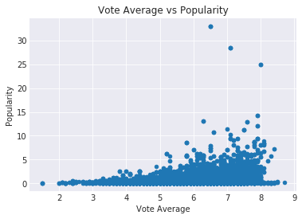

```python
# Use this, and more code cells, to explore your data. Don't forget to add
#   Markdown cells to document your observations and findings.
df_combined.plot(x='vote_average', y='popularity',kind='scatter')
plt.title('Vote Average vs Popularity')
plt.xlabel('Vote Average')
plt.ylabel('Popularity')
plt.show()
```

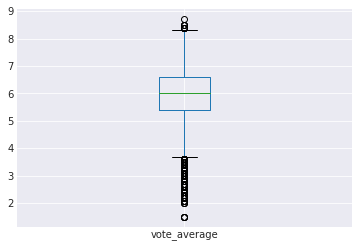

```python
df_combined['vote_average'].plot(kind='box')
plt.show()
```

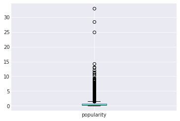

```python
df['popularity'].plot(kind='box')
plt.show()
```

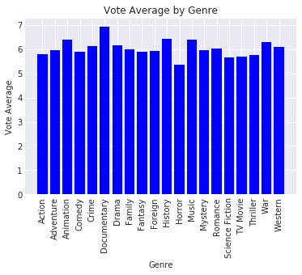

```python
df_genre = df_combined.groupby('genre').mean()
df_genre = df_genre.sort_values('vote_average')
df_genre
plt.bar(df_genre.index, df_genre['vote_average'], color = 'blue')
plt.xticks(rotation='90')
plt.title('Vote Average by Genre')
plt.ylabel('Vote Average')
plt.xlabel('Genre')
plt.show()
```

> To compare vote averge by genre, I used the new dataframe I made while cleaning the data (**df_combined**) to create another dataframe (**df_genre**) that displays the mean value of all columns aggregated by genre type. Then I plotted the **vote average mean** on a bar chart for each genre.

> The chart shows that the lowest rated movies are **Horror**, **Science Fiction**, and **TV Movie**, while the highest rated are **Documentary**, **History**, and **Music**.

Now, let's check for the most popular genre and their year

```python
df_combined['popularity'].describe()
```

```
count    24650.000000
mean         0.750863
std          1.150491
min          0.000188
25%          0.247590
50%          0.441629
75%          0.835676
max         32.985763
Name: popularity, dtype: float64
```

```python
# use groupby to get popular genres
genre_pop = df_combined.groupby(['release_year', 'genre'], as_index=False)['popularity'].mean()
```

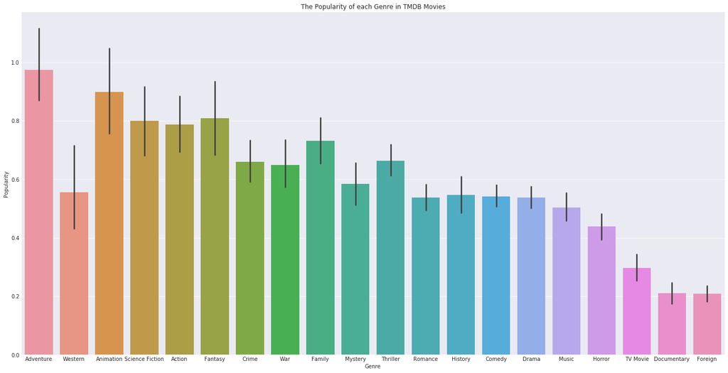

```python
# Plot the The Popularity of each genre in the dataset
plt.figure(figsize=[24,12])
sns.barplot(data=genre_pop.sort_values(by='popularity', ascending=False), x='genre', y='popularity')
plt.xlabel('Genre')
plt.ylabel('Popularity')
plt.title('The Popularity of each Genre in TMDB Movies')
plt.show()
```

From the combined dataset, **Adventure**, **Animation** and **Fantasy** are the top 3 popular genres

```python
# use query to determine the most popular genres
most_popular = df_combined.query('popularity > 10')
```

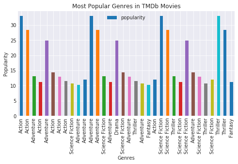

```python
# plot the most popular genre (i.e, genres with popularity higher than 10)
most_popular.plot(x='genre', y='popularity', kind='bar', figsize=(8,4))
plt.title('Most Popular Genres in TMDb Movies')
plt.xlabel('Genres')
plt.ylabel('Popularity')
plt.show()
```

```python
# print most popular genres and their release year
print(most_popular.groupby(['release_year', 'genre'])['popularity'].mean())
```

```
release_year  genre
1977          Action             12.037933
              Adventure          12.037933
              Science Fiction    12.037933
2014          Action             12.901661
              Adventure          14.628995
              Drama              24.949134
              Fantasy            10.174599
              Science Fiction    15.742594
              Thriller           11.080880
2015          Action             24.192934
              Adventure          21.422827
              Fantasy            11.173104
              Science Fiction    21.422827
              Thriller           24.839402
Name: popularity, dtype: float64
```

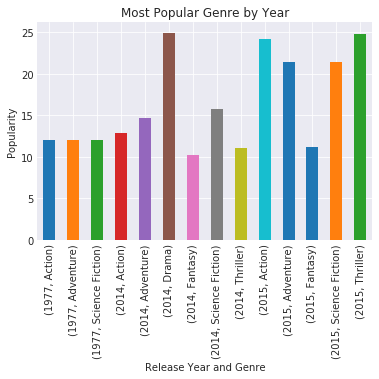

```python
# check the most popular genre for each year
most_popular.groupby(['release_year', 'genre'])['popularity'].mean().plot(kind='bar')
plt.title('Most Popular Genre by Year')
plt.xlabel('Release Year and Genre')
plt.ylabel('Popularity')
plt.show()
```

### Research Question 2: What kinds of properties are associated with movies that have high revenues?

```python
# use query to determine high revenue movies
high_revenue = df_combined.query('revenue > revenue.mean()')
low_revenue = df_combined.query('revenue <= revenue.mean()')
```

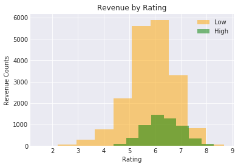

```python
# plot to compare high revenue with low revenue movies
low_revenue.vote_average.plot.hist(color='orange', alpha=0.5, label='Low')
high_revenue.vote_average.plot.hist(color='green', alpha=0.5, label='High')
plt.title('Revenue by Rating')
plt.xlabel('Rating')
plt.ylabel('Revenue Counts')
plt.legend()
plt.show()
```

It is clear that we have more low revenue movies from the dataset. High revenue skewed more to the right while low revenue skewed more to the left. This shows that high revenue movies gained higher rating than the low revenue movies. Therefore, **vote_average** is one of the properties associated with high revenue movies

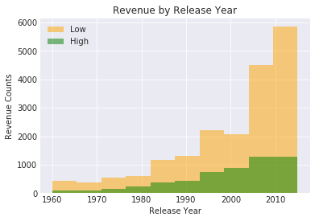

```python
# check the association of high revenue movies with their release year
low_revenue.release_year.plot.hist(color='orange', alpha=0.5, label='Low')
high_revenue.release_year.plot.hist(color='green', alpha=0.5, label='High')
plt.title('Revenue by Release Year')
plt.xlabel('Release Year')
plt.ylabel('Revenue Counts')
plt.legend()
plt.show()
```

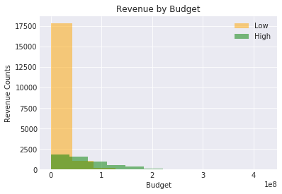

```python
# check the association of high revenue movies with budget
low_revenue.budget.plot.hist(color='orange', alpha=0.5, label='Low')
high_revenue.budget.plot.hist(color='green', alpha=0.5, label='High')
plt.title('Revenue by Budget')
plt.xlabel('Budget')
plt.ylabel('Revenue Counts')
plt.legend()
plt.show()
```

High revenue movies are favoured by high budget as well. Therefore, **budget** is also associated with high revenue movies

## Conclusions

> **Tip**: Finally, summarize your findings and the results that have been performed. Make sure that you are clear with regards to the limitations of your exploration. If you haven't done any statistical tests, do not imply any statistical conclusions. And make sure you avoid implying causation from correlation!

> **Tip**: Once you are satisfied with your work here, check over your report to make sure that it is satisfies all the areas of the rubric (found on the project submission page at the end of the lesson). You should also probably remove all of the "Tips" like this one so that the presentation is as polished as possible.

> There are many qualities about movies that make them unique from one another. In this project, I was able to analyze these qualities and identify which properties are associated with movie popularity and high revenue.

> After cleaning and trimming the dataset by removing unnecessary, null, and duplicated values, I created a secondary table that broke each movie down into the separate genre it falls under. Then I plotted a few charts to assess what will be used as the dependent variable, popularity and vote average.

### Findings

> Since my analysis only illustrates correlation between variables, it does not definitively conclude whether any trait can predict the popularity and revenue status of a movie. That would require deeper statistical analysis that was not performed in this project.

## Submitting your Project

> Before you submit your project, you need to create a .html or .pdf version of this notebook in the workspace here. To do that, run the code cell below. If it worked correctly, you should get a return code of 0, and you should see the generated .html file in the workspace directory (click on the orange Jupyter icon in the upper left).

> Alternatively, you can download this report as .html via the **File** > **Download as** submenu, and then manually upload it into the workspace directory by clicking on the orange Jupyter icon in the upper left, then using the Upload button.

> Once you've done this, you can submit your project by clicking on the "Submit Project" button in the lower right here. This will create and submit a zip file with this .ipynb doc and the .html or .pdf version you created. Congratulations!

```python
from subprocess import call
call(['python', '-m', 'nbconvert', 'Investigate_a_Dataset.ipynb'])
```

```
0
```